# 326.212 Homework 1

#### Problem 5. What does the stroke aesthetic do? What shapes does it work with? (Hint: use ?geom_point)

geom_point의 help document에 의하면, stroke의 경우 geom_point의 argument로 사용되어, shape가 21~25일 경우 점의 테두리 두께를 결정하는데에 사용된다.

예를들어, 다음과 같이 사용할 수 있다.

size = 5, stroke = 2의 경우

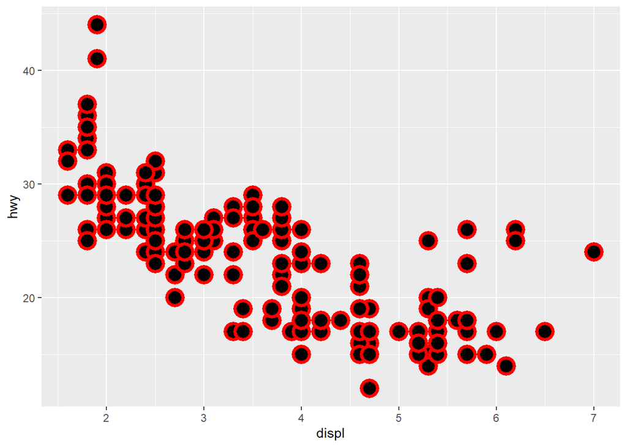

```r
ggplot(data = mpg) + geom_point(mapping = aes(x = displ, y = hwy), shape =21, color = "red", size = 5, fill = "black", stroke = 2)
```

size = 5, stroke = 10의 경우

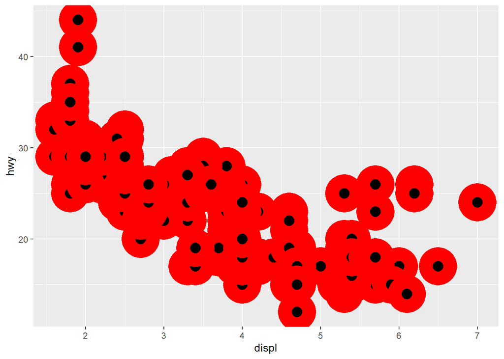

```r
ggplot(data = mpg) + geom_point(mapping = aes(x = displ, y = hwy), shape =21, color = "red", size = 5, fill = "black", stroke = 10)
```